# Risk Factor Analysis

## Outcome Variable

**Outcome Variable:** whz

## Predictor Variables

**Intervention Variable:** predfeed3

**Adjustment Set:**

- arm
- sex
- month
- brthmon
- W_mage
- meducyrs
- feducyrs
- hhwealth_quart
- hfoodsec
- W_mhtcm
- W_mwtkg
- W_mbmi
- vagbrth
- W_gagebrth
- W_birthwt
- W_birthlen
- W_nrooms
- W_nchldlt5
- W_parity
- impfloor
- impsan
- safeh20
- delta_W_mage
- delta_meducyrs
- delta_feducyrs
- delta_hhwealth_quart
- delta_hfoodsec
- delta_W_mhtcm
- delta_W_mwtkg
- delta_W_mbmi
- delta_vagbrth
- delta_W_gagebrth
- delta_W_birthwt
- delta_W_birthlen
- delta_W_nrooms
- delta_W_nchldlt5
- delta_W_parity
- delta_impfloor
- delta_impsan
- delta_safeh20

## Stratifying Variables

The analysis was stratified on these variable(s):

- agecat
- studyid
- country

## Data Summary

| agecat | studyid | country | predfeed3 | n_cell | n |
| --- | --- | --- | --- | --- | --- |
| Birth | ki0047075b-MAL-ED | BANGLADESH | 1 | 164 | 202 |
| Birth | ki0047075b-MAL-ED | BANGLADESH | 0 | 38 | 202 |
| Birth | ki0047075b-MAL-ED | BRAZIL | 1 | 23 | 55 |
| Birth | ki0047075b-MAL-ED | BRAZIL | 0 | 32 | 55 |
| Birth | ki0047075b-MAL-ED | INDIA | 1 | 27 | 39 |
| Birth | ki0047075b-MAL-ED | INDIA | 0 | 12 | 39 |
| Birth | ki0047075b-MAL-ED | NEPAL | 1 | 14 | 25 |
| Birth | ki0047075b-MAL-ED | NEPAL | 0 | 11 | 25 |
| Birth | ki0047075b-MAL-ED | PERU | 1 | 145 | 218 |
| Birth | ki0047075b-MAL-ED | PERU | 0 | 73 | 218 |
| Birth | ki0047075b-MAL-ED | SOUTH AFRICA | 1 | 33 | 99 |
| Birth | ki0047075b-MAL-ED | SOUTH AFRICA | 0 | 66 | 99 |
| Birth | ki0047075b-MAL-ED | TANZANIA, UNITED REPUBLIC OF | 1 | 24 | 95 |
| Birth | ki0047075b-MAL-ED | TANZANIA, UNITED REPUBLIC OF | 0 | 71 | 95 |
| Birth | ki1000109-EE | PAKISTAN | 1 | 22 | 22 |
| Birth | ki1000109-EE | PAKISTAN | 0 | 0 | 22 |
| Birth | ki1113344-GMS-Nepal | NEPAL | 1 | 352 | 422 |
| Birth | ki1113344-GMS-Nepal | NEPAL | 0 | 70 | 422 |
| Birth | kiGH5241-JiVitA-3 | BANGLADESH | 1 | 10997 | 12129 |
| Birth | kiGH5241-JiVitA-3 | BANGLADESH | 0 | 1132 | 12129 |
| Birth | kiGH5241-JiVitA-4 | BANGLADESH | 1 | 89 | 97 |
| Birth | kiGH5241-JiVitA-4 | BANGLADESH | 0 | 8 | 97 |
| 6 months | ki0047075b-MAL-ED | BANGLADESH | 1 | 191 | 233 |
| 6 months | ki0047075b-MAL-ED | BANGLADESH | 0 | 42 | 233 |
| 6 months | ki0047075b-MAL-ED | BRAZIL | 1 | 93 | 187 |
| 6 months | ki0047075b-MAL-ED | BRAZIL | 0 | 94 | 187 |
| 6 months | ki0047075b-MAL-ED | INDIA | 1 | 147 | 210 |
| 6 months | ki0047075b-MAL-ED | INDIA | 0 | 63 | 210 |
| 6 months | ki0047075b-MAL-ED | NEPAL | 1 | 113 | 227 |
| 6 months | ki0047075b-MAL-ED | NEPAL | 0 | 114 | 227 |
| 6 months | ki0047075b-MAL-ED | PERU | 1 | 176 | 270 |
| 6 months | ki0047075b-MAL-ED | PERU | 0 | 94 | 270 |
| 6 months | ki0047075b-MAL-ED | SOUTH AFRICA | 1 | 63 | 244 |
| 6 months | ki0047075b-MAL-ED | SOUTH AFRICA | 0 | 181 | 244 |
| 6 months | ki0047075b-MAL-ED | TANZANIA, UNITED REPUBLIC OF | 1 | 64 | 212 |
| 6 months | ki0047075b-MAL-ED | TANZANIA, UNITED REPUBLIC OF | 0 | 148 | 212 |
| 6 months | ki1000109-EE | PAKISTAN | 1 | 39 | 39 |
| 6 months | ki1000109-EE | PAKISTAN | 0 | 0 | 39 |
| 6 months | ki1113344-GMS-Nepal | NEPAL | 1 | 367 | 441 |
| 6 months | ki1113344-GMS-Nepal | NEPAL | 0 | 74 | 441 |
| 6 months | kiGH5241-JiVitA-3 | BANGLADESH | 1 | 8481 | 9289 |
| 6 months | kiGH5241-JiVitA-3 | BANGLADESH | 0 | 808 | 9289 |
| 6 months | kiGH5241-JiVitA-4 | BANGLADESH | 1 | 76 | 88 |
| 6 months | kiGH5241-JiVitA-4 | BANGLADESH | 0 | 12 | 88 |
| 24 months | ki0047075b-MAL-ED | BANGLADESH | 1 | 168 | 205 |
| 24 months | ki0047075b-MAL-ED | BANGLADESH | 0 | 37 | 205 |
| 24 months | ki0047075b-MAL-ED | BRAZIL | 1 | 79 | 152 |
| 24 months | ki0047075b-MAL-ED | BRAZIL | 0 | 73 | 152 |
| 24 months | ki0047075b-MAL-ED | INDIA | 1 | 139 | 202 |
| 24 months | ki0047075b-MAL-ED | INDIA | 0 | 63 | 202 |
| 24 months | ki0047075b-MAL-ED | NEPAL | 1 | 110 | 220 |
| 24 months | ki0047075b-MAL-ED | NEPAL | 0 | 110 | 220 |
| 24 months | ki0047075b-MAL-ED | PERU | 1 | 131 | 198 |
| 24 months | ki0047075b-MAL-ED | PERU | 0 | 67 | 198 |
| 24 months | ki0047075b-MAL-ED | SOUTH AFRICA | 1 | 60 | 228 |
| 24 months | ki0047075b-MAL-ED | SOUTH AFRICA | 0 | 168 | 228 |
| 24 months | ki0047075b-MAL-ED | TANZANIA, UNITED REPUBLIC OF | 1 | 54 | 184 |
| 24 months | ki0047075b-MAL-ED | TANZANIA, UNITED REPUBLIC OF | 0 | 130 | 184 |
| 24 months | ki1000109-EE | PAKISTAN | 1 | 20 | 20 |
| 24 months | ki1000109-EE | PAKISTAN | 0 | 0 | 20 |
| 24 months | ki1113344-GMS-Nepal | NEPAL | 1 | 322 | 384 |
| 24 months | ki1113344-GMS-Nepal | NEPAL | 0 | 62 | 384 |
| 24 months | kiGH5241-JiVitA-3 | BANGLADESH | 1 | 4381 | 4795 |
| 24 months | kiGH5241-JiVitA-3 | BANGLADESH | 0 | 414 | 4795 |
| 24 months | kiGH5241-JiVitA-4 | BANGLADESH | 1 | 135 | 150 |
| 24 months | kiGH5241-JiVitA-4 | BANGLADESH | 0 | 15 | 150 |

The following strata were considered:

- agecat: 24 months, studyid: ki0047075b-MAL-ED, country: BANGLADESH
- agecat: 24 months, studyid: ki0047075b-MAL-ED, country: BRAZIL
- agecat: 24 months, studyid: ki0047075b-MAL-ED, country: INDIA
- agecat: 24 months, studyid: ki0047075b-MAL-ED, country: NEPAL
- agecat: 24 months, studyid: ki0047075b-MAL-ED, country: PERU
- agecat: 24 months, studyid: ki0047075b-MAL-ED, country: SOUTH AFRICA
- agecat: 24 months, studyid: ki0047075b-MAL-ED, country: TANZANIA, UNITED REPUBLIC OF
- agecat: 24 months, studyid: ki1000109-EE, country: PAKISTAN
- agecat: 24 months, studyid: ki1113344-GMS-Nepal, country: NEPAL
- agecat: 24 months, studyid: kiGH5241-JiVitA-3, country: BANGLADESH
- agecat: 24 months, studyid: kiGH5241-JiVitA-4, country: BANGLADESH
- agecat: 6 months, studyid: ki0047075b-MAL-ED, country: BANGLADESH
- agecat: 6 months, studyid: ki0047075b-MAL-ED, country: BRAZIL
- agecat: 6 months, studyid: ki0047075b-MAL-ED, country: INDIA
- agecat: 6 months, studyid: ki0047075b-MAL-ED, country: NEPAL
- agecat: 6 months, studyid: ki0047075b-MAL-ED, country: PERU
- agecat: 6 months, studyid: ki0047075b-MAL-ED, country: SOUTH AFRICA
- agecat: 6 months, studyid: ki0047075b-MAL-ED, country: TANZANIA, UNITED REPUBLIC OF
- agecat: 6 months, studyid: ki1000109-EE, country: PAKISTAN
- agecat: 6 months, studyid: ki1113344-GMS-Nepal, country: NEPAL
- agecat: 6 months, studyid: kiGH5241-JiVitA-3, country: BANGLADESH
- agecat: 6 months, studyid: kiGH5241-JiVitA-4, country: BANGLADESH
- agecat: Birth, studyid: ki0047075b-MAL-ED, country: BANGLADESH
- agecat: Birth, studyid: ki0047075b-MAL-ED, country: BRAZIL
- agecat: Birth, studyid: ki0047075b-MAL-ED, country: INDIA
- agecat: Birth, studyid: ki0047075b-MAL-ED, country: NEPAL
- agecat: Birth, studyid: ki0047075b-MAL-ED, country: PERU
- agecat: Birth, studyid: ki0047075b-MAL-ED, country: SOUTH AFRICA
- agecat: Birth, studyid: ki0047075b-MAL-ED, country: TANZANIA, UNITED REPUBLIC OF
- agecat: Birth, studyid: ki1000109-EE, country: PAKISTAN
- agecat: Birth, studyid: ki1113344-GMS-Nepal, country: NEPAL
- agecat: Birth, studyid: kiGH5241-JiVitA-3, country: BANGLADESH
- agecat: Birth, studyid: kiGH5241-JiVitA-4, country: BANGLADESH

### Dropped Strata

- agecat: Birth, studyid: ki1000109-EE, country: PAKISTAN
- agecat: 6 months, studyid: ki1000109-EE, country: PAKISTAN
- agecat: 24 months, studyid: ki1000109-EE, country: PAKISTAN

## Methods Detail

We’re interested in the causal parameters $E[Y_a]$ for all values of $a \in \mathcal{A}$. These parameters represent the mean outcome if, possibly contrary to fact, we intervened to set all units to have $A=a$. Under the randomization and positivity assumptions, these are identified by the statistical parameters $\psi_a=E_W[E_{Y|A,W}(Y|A=a,W)]$. In addition, we’re interested in the mean of $Y$, $E[Y]$ under no intervention (the observed mean). We will estimate these parameters by using SuperLearner to fit the relevant likelihood factors – $E_{Y|A,W}(Y|A=a,W)$ and $p(A=a|W)$, and then updating our likelihood fit using a joint TMLE.

For unadjusted analyses ($W=\{\}$), initial likelihoods were estimated using Lrnr_glm to estimate the simple $E(Y|A)$ and Lrnr_mean to estimate $p(A)$. For adjusted analyses, a small library containing Lrnr_glmnet, Lrnr_xgboost, and Lrnr_mean was used.

Having estimated these parameters, we will then use the delta method to estimate relative risks and attributable risks relative to a prespecified baseline level of $A$.

# Results Detail

## Results Plots

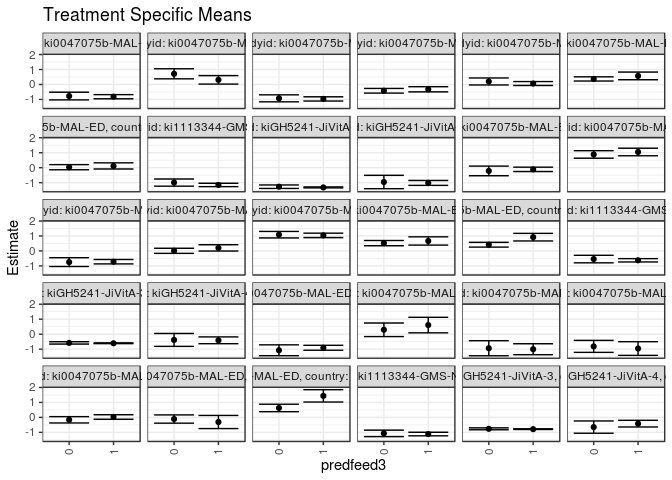

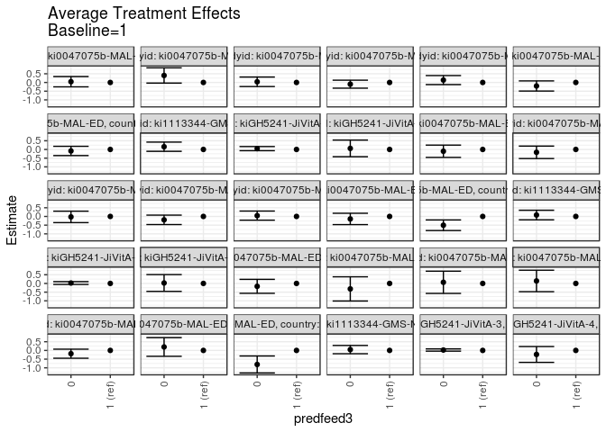

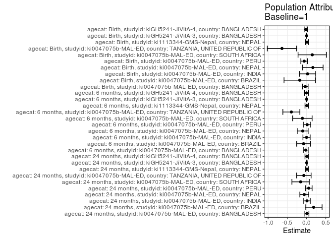

## Results Table

### Parameter: TSM

| agecat | studyid | country | intervention_level | baseline_level | estimate | ci_lower | ci_upper |
| --- | --- | --- | --- | --- | --- | --- | --- |
| Birth | ki0047075b-MAL-ED | BANGLADESH | 1 | NA | -0.9082105 | -1.0741933 | -0.7422277 |
| Birth | ki0047075b-MAL-ED | BANGLADESH | 0 | NA | -1.0750009 | -1.4367877 | -0.7132141 |
| Birth | ki0047075b-MAL-ED | BRAZIL | 1 | NA | 0.6080647 | 0.0881706 | 1.1279589 |
| Birth | ki0047075b-MAL-ED | BRAZIL | 0 | NA | 0.2936705 | -0.1588629 | 0.7462039 |
| Birth | ki0047075b-MAL-ED | INDIA | 1 | NA | -1.0043099 | -1.3703980 | -0.6382217 |
| Birth | ki0047075b-MAL-ED | INDIA | 0 | NA | -0.9386390 | -1.4424784 | -0.4347995 |
| Birth | ki0047075b-MAL-ED | NEPAL | 1 | NA | -0.9584273 | -1.4148847 | -0.5019699 |
| Birth | ki0047075b-MAL-ED | NEPAL | 0 | NA | -0.8159386 | -1.2153834 | -0.4164937 |
| Birth | ki0047075b-MAL-ED | PERU | 1 | NA | 0.0269203 | -0.1239270 | 0.1777675 |
| Birth | ki0047075b-MAL-ED | PERU | 0 | NA | -0.1607777 | -0.3723845 | 0.0508290 |
| Birth | ki0047075b-MAL-ED | SOUTH AFRICA | 1 | NA | -0.3071541 | -0.7454940 | 0.1311858 |
| Birth | ki0047075b-MAL-ED | SOUTH AFRICA | 0 | NA | -0.1083546 | -0.3851348 | 0.1684256 |
| Birth | ki0047075b-MAL-ED | TANZANIA, UNITED REPUBLIC OF | 1 | NA | 1.4388778 | 1.0269649 | 1.8507906 |
| Birth | ki0047075b-MAL-ED | TANZANIA, UNITED REPUBLIC OF | 0 | NA | 0.6308811 | 0.3822109 | 0.8795513 |
| Birth | ki1113344-GMS-Nepal | NEPAL | 1 | NA | -1.1123893 | -1.2315572 | -0.9932213 |
| Birth | ki1113344-GMS-Nepal | NEPAL | 0 | NA | -1.0658045 | -1.2820505 | -0.8495586 |
| Birth | kiGH5241-JiVitA-3 | BANGLADESH | 1 | NA | -0.7842372 | -0.8067037 | -0.7617707 |
| Birth | kiGH5241-JiVitA-3 | BANGLADESH | 0 | NA | -0.7619135 | -0.8248917 | -0.6989352 |
| Birth | kiGH5241-JiVitA-4 | BANGLADESH | 1 | NA | -0.4156180 | -0.6383645 | -0.1928714 |
| Birth | kiGH5241-JiVitA-4 | BANGLADESH | 0 | NA | -0.6475000 | -1.0569566 | -0.2380434 |
| 6 months | ki0047075b-MAL-ED | BANGLADESH | 1 | NA | -0.1102128 | -0.2558665 | 0.0354410 |
| 6 months | ki0047075b-MAL-ED | BANGLADESH | 0 | NA | -0.2134907 | -0.5358194 | 0.1088381 |
| 6 months | ki0047075b-MAL-ED | BRAZIL | 1 | NA | 1.0506540 | 0.7982701 | 1.3030380 |
| 6 months | ki0047075b-MAL-ED | BRAZIL | 0 | NA | 0.8858822 | 0.6349522 | 1.1368123 |
| 6 months | ki0047075b-MAL-ED | INDIA | 1 | NA | -0.7190092 | -0.8659118 | -0.5721065 |
| 6 months | ki0047075b-MAL-ED | INDIA | 0 | NA | -0.7448856 | -1.0389464 | -0.4508247 |
| 6 months | ki0047075b-MAL-ED | NEPAL | 1 | NA | 0.2047160 | -0.0057384 | 0.4151704 |
| 6 months | ki0047075b-MAL-ED | NEPAL | 0 | NA | 0.0088547 | -0.1615642 | 0.1792736 |
| 6 months | ki0047075b-MAL-ED | PERU | 1 | NA | 1.0391092 | 0.8917687 | 1.1864498 |
| 6 months | ki0047075b-MAL-ED | PERU | 0 | NA | 1.0862008 | 0.8692383 | 1.3031632 |
| 6 months | ki0047075b-MAL-ED | SOUTH AFRICA | 1 | NA | 0.6656919 | 0.3893090 | 0.9420748 |
| 6 months | ki0047075b-MAL-ED | SOUTH AFRICA | 0 | NA | 0.5221478 | 0.3471283 | 0.6971674 |
| 6 months | ki0047075b-MAL-ED | TANZANIA, UNITED REPUBLIC OF | 1 | NA | 0.9207556 | 0.6672533 | 1.1742578 |
| 6 months | ki0047075b-MAL-ED | TANZANIA, UNITED REPUBLIC OF | 0 | NA | 0.4150785 | 0.2550013 | 0.5751556 |
| 6 months | ki1113344-GMS-Nepal | NEPAL | 1 | NA | -0.6255191 | -0.7358071 | -0.5152311 |
| 6 months | ki1113344-GMS-Nepal | NEPAL | 0 | NA | -0.5433237 | -0.7952549 | -0.2913924 |
| 6 months | kiGH5241-JiVitA-3 | BANGLADESH | 1 | NA | -0.6061442 | -0.6316529 | -0.5806355 |
| 6 months | kiGH5241-JiVitA-3 | BANGLADESH | 0 | NA | -0.5829824 | -0.6602150 | -0.5057498 |
| 6 months | kiGH5241-JiVitA-4 | BANGLADESH | 1 | NA | -0.4099718 | -0.6363526 | -0.1835911 |
| 6 months | kiGH5241-JiVitA-4 | BANGLADESH | 0 | NA | -0.3842011 | -0.8148973 | 0.0464950 |
| 24 months | ki0047075b-MAL-ED | BANGLADESH | 1 | NA | -0.8171535 | -0.9568047 | -0.6775022 |
| 24 months | ki0047075b-MAL-ED | BANGLADESH | 0 | NA | -0.7728628 | -1.0293699 | -0.5163556 |
| 24 months | ki0047075b-MAL-ED | BRAZIL | 1 | NA | 0.3097987 | 0.0265200 | 0.5930774 |
| 24 months | ki0047075b-MAL-ED | BRAZIL | 0 | NA | 0.7119280 | 0.3757511 | 1.0481049 |
| 24 months | ki0047075b-MAL-ED | INDIA | 1 | NA | -0.9639275 | -1.1046350 | -0.8232200 |
| 24 months | ki0047075b-MAL-ED | INDIA | 0 | NA | -0.9248051 | -1.1580761 | -0.6915341 |
| 24 months | ki0047075b-MAL-ED | NEPAL | 1 | NA | -0.3216824 | -0.4935839 | -0.1497808 |
| 24 months | ki0047075b-MAL-ED | NEPAL | 0 | NA | -0.4202920 | -0.5768018 | -0.2637823 |
| 24 months | ki0047075b-MAL-ED | PERU | 1 | NA | 0.0634268 | -0.0663606 | 0.1932142 |
| 24 months | ki0047075b-MAL-ED | PERU | 0 | NA | 0.2010894 | -0.0319597 | 0.4341385 |
| 24 months | ki0047075b-MAL-ED | SOUTH AFRICA | 1 | NA | 0.5728665 | 0.3171181 | 0.8286150 |
| 24 months | ki0047075b-MAL-ED | SOUTH AFRICA | 0 | NA | 0.3710829 | 0.2313205 | 0.5108453 |
| 24 months | ki0047075b-MAL-ED | TANZANIA, UNITED REPUBLIC OF | 1 | NA | 0.1194324 | -0.0856408 | 0.3245056 |
| 24 months | ki0047075b-MAL-ED | TANZANIA, UNITED REPUBLIC OF | 0 | NA | 0.0337149 | -0.1385387 | 0.2059686 |
| 24 months | ki1113344-GMS-Nepal | NEPAL | 1 | NA | -1.1512491 | -1.2636551 | -1.0388430 |
| 24 months | ki1113344-GMS-Nepal | NEPAL | 0 | NA | -0.9937173 | -1.2336144 | -0.7538202 |
| 24 months | kiGH5241-JiVitA-3 | BANGLADESH | 1 | NA | -1.3161864 | -1.3482616 | -1.2841112 |
| 24 months | kiGH5241-JiVitA-3 | BANGLADESH | 0 | NA | -1.2676336 | -1.3837780 | -1.1514893 |
| 24 months | kiGH5241-JiVitA-4 | BANGLADESH | 1 | NA | -1.0160426 | -1.1795103 | -0.8525749 |
| 24 months | kiGH5241-JiVitA-4 | BANGLADESH | 0 | NA | -0.9552198 | -1.4018265 | -0.5086132 |

### Parameter: E(Y)

| agecat | studyid | country | intervention_level | baseline_level | estimate | ci_lower | ci_upper |
| --- | --- | --- | --- | --- | --- | --- | --- |
| Birth | ki0047075b-MAL-ED | BANGLADESH | NA | NA | -0.9404455 | -1.0889530 | -0.7919381 |
| Birth | ki0047075b-MAL-ED | BRAZIL | NA | NA | 0.4316364 | 0.0969688 | 0.7663039 |
| Birth | ki0047075b-MAL-ED | INDIA | NA | NA | -0.9779487 | -1.2664810 | -0.6894164 |
| Birth | ki0047075b-MAL-ED | NEPAL | NA | NA | -0.7944000 | -1.1625222 | -0.4262778 |
| Birth | ki0047075b-MAL-ED | PERU | NA | NA | -0.0335321 | -0.1564905 | 0.0894263 |
| Birth | ki0047075b-MAL-ED | SOUTH AFRICA | NA | NA | -0.1588889 | -0.3845288 | 0.0667510 |
| Birth | ki0047075b-MAL-ED | TANZANIA, UNITED REPUBLIC OF | NA | NA | 0.7996842 | 0.5874808 | 1.0118876 |
| Birth | ki1113344-GMS-Nepal | NEPAL | NA | NA | -1.0991706 | -1.2073693 | -0.9909719 |
| Birth | kiGH5241-JiVitA-3 | BANGLADESH | NA | NA | -0.7822228 | -0.8038489 | -0.7605966 |
| Birth | kiGH5241-JiVitA-4 | BANGLADESH | NA | NA | -0.4347423 | -0.6441144 | -0.2253701 |
| 6 months | ki0047075b-MAL-ED | BANGLADESH | NA | NA | -0.1312375 | -0.2633777 | 0.0009027 |
| 6 months | ki0047075b-MAL-ED | BRAZIL | NA | NA | 0.9730392 | 0.7966084 | 1.1494700 |
| 6 months | ki0047075b-MAL-ED | INDIA | NA | NA | -0.7190952 | -0.8496984 | -0.5884921 |
| 6 months | ki0047075b-MAL-ED | NEPAL | NA | NA | 0.1047871 | -0.0305193 | 0.2400934 |
| 6 months | ki0047075b-MAL-ED | PERU | NA | NA | 1.0554753 | 0.9329598 | 1.1779909 |
| 6 months | ki0047075b-MAL-ED | SOUTH AFRICA | NA | NA | 0.5569945 | 0.4061636 | 0.7078255 |
| 6 months | ki0047075b-MAL-ED | TANZANIA, UNITED REPUBLIC OF | NA | NA | 0.5257626 | 0.3871543 | 0.6643709 |
| 6 months | ki1113344-GMS-Nepal | NEPAL | NA | NA | -0.6198791 | -0.7206518 | -0.5191063 |
| 6 months | kiGH5241-JiVitA-3 | BANGLADESH | NA | NA | -0.6040726 | -0.6286341 | -0.5795110 |
| 6 months | kiGH5241-JiVitA-4 | BANGLADESH | NA | NA | -0.4110227 | -0.6122701 | -0.2097753 |
| 24 months | ki0047075b-MAL-ED | BANGLADESH | NA | NA | -0.8086098 | -0.9307952 | -0.6864243 |
| 24 months | ki0047075b-MAL-ED | BRAZIL | NA | NA | 0.4943421 | 0.2716679 | 0.7170163 |
| 24 months | ki0047075b-MAL-ED | INDIA | NA | NA | -0.9524010 | -1.0710590 | -0.8337430 |
| 24 months | ki0047075b-MAL-ED | NEPAL | NA | NA | -0.3806364 | -0.4971717 | -0.2641010 |
| 24 months | ki0047075b-MAL-ED | PERU | NA | NA | 0.1199242 | 0.0008627 | 0.2389858 |
| 24 months | ki0047075b-MAL-ED | SOUTH AFRICA | NA | NA | 0.4181579 | 0.2964894 | 0.5398263 |
| 24 months | ki0047075b-MAL-ED | TANZANIA, UNITED REPUBLIC OF | NA | NA | 0.0485870 | -0.0868148 | 0.1839888 |
| 24 months | ki1113344-GMS-Nepal | NEPAL | NA | NA | -1.1396441 | -1.2416403 | -1.0376479 |
| 24 months | kiGH5241-JiVitA-3 | BANGLADESH | NA | NA | -1.3119979 | -1.3435475 | -1.2804484 |
| 24 months | kiGH5241-JiVitA-4 | BANGLADESH | NA | NA | -1.0096000 | -1.1619164 | -0.8572836 |

### Parameter: ATE

| agecat | studyid | country | intervention_level | baseline_level | estimate | ci_lower | ci_upper |
| --- | --- | --- | --- | --- | --- | --- | --- |
| Birth | ki0047075b-MAL-ED | BANGLADESH | 1 | 1 | 0.0000000 | 0.0000000 | 0.0000000 |
| Birth | ki0047075b-MAL-ED | BANGLADESH | 0 | 1 | -0.1667904 | -0.5673059 | 0.2337251 |
| Birth | ki0047075b-MAL-ED | BRAZIL | 1 | 1 | 0.0000000 | 0.0000000 | 0.0000000 |
| Birth | ki0047075b-MAL-ED | BRAZIL | 0 | 1 | -0.3143942 | -1.0104612 | 0.3816728 |
| Birth | ki0047075b-MAL-ED | INDIA | 1 | 1 | 0.0000000 | 0.0000000 | 0.0000000 |
| Birth | ki0047075b-MAL-ED | INDIA | 0 | 1 | 0.0656709 | -0.5737968 | 0.7051386 |
| Birth | ki0047075b-MAL-ED | NEPAL | 1 | 1 | 0.0000000 | 0.0000000 | 0.0000000 |
| Birth | ki0047075b-MAL-ED | NEPAL | 0 | 1 | 0.1424887 | -0.4744909 | 0.7594684 |
| Birth | ki0047075b-MAL-ED | PERU | 1 | 1 | 0.0000000 | 0.0000000 | 0.0000000 |
| Birth | ki0047075b-MAL-ED | PERU | 0 | 1 | -0.1876980 | -0.4479067 | 0.0725108 |
| Birth | ki0047075b-MAL-ED | SOUTH AFRICA | 1 | 1 | 0.0000000 | 0.0000000 | 0.0000000 |
| Birth | ki0047075b-MAL-ED | SOUTH AFRICA | 0 | 1 | 0.1987995 | -0.3386380 | 0.7362370 |
| Birth | ki0047075b-MAL-ED | TANZANIA, UNITED REPUBLIC OF | 1 | 1 | 0.0000000 | 0.0000000 | 0.0000000 |
| Birth | ki0047075b-MAL-ED | TANZANIA, UNITED REPUBLIC OF | 0 | 1 | -0.8079967 | -1.2957445 | -0.3202489 |
| Birth | ki1113344-GMS-Nepal | NEPAL | 1 | 1 | 0.0000000 | 0.0000000 | 0.0000000 |
| Birth | ki1113344-GMS-Nepal | NEPAL | 0 | 1 | 0.0465847 | -0.1915289 | 0.2846983 |
| Birth | kiGH5241-JiVitA-3 | BANGLADESH | 1 | 1 | 0.0000000 | 0.0000000 | 0.0000000 |
| Birth | kiGH5241-JiVitA-3 | BANGLADESH | 0 | 1 | 0.0223238 | -0.0428686 | 0.0875161 |
| Birth | kiGH5241-JiVitA-4 | BANGLADESH | 1 | 1 | 0.0000000 | 0.0000000 | 0.0000000 |
| Birth | kiGH5241-JiVitA-4 | BANGLADESH | 0 | 1 | -0.2318820 | -0.6871466 | 0.2233826 |
| 6 months | ki0047075b-MAL-ED | BANGLADESH | 1 | 1 | 0.0000000 | 0.0000000 | 0.0000000 |
| 6 months | ki0047075b-MAL-ED | BANGLADESH | 0 | 1 | -0.1032779 | -0.4575018 | 0.2509460 |
| 6 months | ki0047075b-MAL-ED | BRAZIL | 1 | 1 | 0.0000000 | 0.0000000 | 0.0000000 |
| 6 months | ki0047075b-MAL-ED | BRAZIL | 0 | 1 | -0.1647718 | -0.5219489 | 0.1924053 |
| 6 months | ki0047075b-MAL-ED | INDIA | 1 | 1 | 0.0000000 | 0.0000000 | 0.0000000 |
| 6 months | ki0047075b-MAL-ED | INDIA | 0 | 1 | -0.0258764 | -0.3554490 | 0.3036962 |
| 6 months | ki0047075b-MAL-ED | NEPAL | 1 | 1 | 0.0000000 | 0.0000000 | 0.0000000 |
| 6 months | ki0047075b-MAL-ED | NEPAL | 0 | 1 | -0.1958613 | -0.4667375 | 0.0750148 |
| 6 months | ki0047075b-MAL-ED | PERU | 1 | 1 | 0.0000000 | 0.0000000 | 0.0000000 |
| 6 months | ki0047075b-MAL-ED | PERU | 0 | 1 | 0.0470915 | -0.2149169 | 0.3091000 |
| 6 months | ki0047075b-MAL-ED | SOUTH AFRICA | 1 | 1 | 0.0000000 | 0.0000000 | 0.0000000 |
| 6 months | ki0047075b-MAL-ED | SOUTH AFRICA | 0 | 1 | -0.1435441 | -0.4699355 | 0.1828473 |
| 6 months | ki0047075b-MAL-ED | TANZANIA, UNITED REPUBLIC OF | 1 | 1 | 0.0000000 | 0.0000000 | 0.0000000 |
| 6 months | ki0047075b-MAL-ED | TANZANIA, UNITED REPUBLIC OF | 0 | 1 | -0.5056771 | -0.8099160 | -0.2014382 |
| 6 months | ki1113344-GMS-Nepal | NEPAL | 1 | 1 | 0.0000000 | 0.0000000 | 0.0000000 |
| 6 months | ki1113344-GMS-Nepal | NEPAL | 0 | 1 | 0.0821954 | -0.1926927 | 0.3570836 |
| 6 months | kiGH5241-JiVitA-3 | BANGLADESH | 1 | 1 | 0.0000000 | 0.0000000 | 0.0000000 |
| 6 months | kiGH5241-JiVitA-3 | BANGLADESH | 0 | 1 | 0.0231618 | -0.0569704 | 0.1032940 |
| 6 months | kiGH5241-JiVitA-4 | BANGLADESH | 1 | 1 | 0.0000000 | 0.0000000 | 0.0000000 |
| 6 months | kiGH5241-JiVitA-4 | BANGLADESH | 0 | 1 | 0.0257707 | -0.4578336 | 0.5093750 |
| 24 months | ki0047075b-MAL-ED | BANGLADESH | 1 | 1 | 0.0000000 | 0.0000000 | 0.0000000 |
| 24 months | ki0047075b-MAL-ED | BANGLADESH | 0 | 1 | 0.0442907 | -0.2512990 | 0.3398804 |
| 24 months | ki0047075b-MAL-ED | BRAZIL | 1 | 1 | 0.0000000 | 0.0000000 | 0.0000000 |
| 24 months | ki0047075b-MAL-ED | BRAZIL | 0 | 1 | 0.4021293 | -0.0368555 | 0.8411140 |
| 24 months | ki0047075b-MAL-ED | INDIA | 1 | 1 | 0.0000000 | 0.0000000 | 0.0000000 |
| 24 months | ki0047075b-MAL-ED | INDIA | 0 | 1 | 0.0391224 | -0.2336615 | 0.3119063 |
| 24 months | ki0047075b-MAL-ED | NEPAL | 1 | 1 | 0.0000000 | 0.0000000 | 0.0000000 |
| 24 months | ki0047075b-MAL-ED | NEPAL | 0 | 1 | -0.0986097 | -0.3287057 | 0.1314863 |
| 24 months | ki0047075b-MAL-ED | PERU | 1 | 1 | 0.0000000 | 0.0000000 | 0.0000000 |
| 24 months | ki0047075b-MAL-ED | PERU | 0 | 1 | 0.1376626 | -0.1224875 | 0.3978127 |
| 24 months | ki0047075b-MAL-ED | SOUTH AFRICA | 1 | 1 | 0.0000000 | 0.0000000 | 0.0000000 |
| 24 months | ki0047075b-MAL-ED | SOUTH AFRICA | 0 | 1 | -0.2017836 | -0.4937612 | 0.0901940 |
| 24 months | ki0047075b-MAL-ED | TANZANIA, UNITED REPUBLIC OF | 1 | 1 | 0.0000000 | 0.0000000 | 0.0000000 |
| 24 months | ki0047075b-MAL-ED | TANZANIA, UNITED REPUBLIC OF | 0 | 1 | -0.0857174 | -0.3517731 | 0.1803383 |
| 24 months | ki1113344-GMS-Nepal | NEPAL | 1 | 1 | 0.0000000 | 0.0000000 | 0.0000000 |
| 24 months | ki1113344-GMS-Nepal | NEPAL | 0 | 1 | 0.1575318 | -0.1073183 | 0.4223819 |
| 24 months | kiGH5241-JiVitA-3 | BANGLADESH | 1 | 1 | 0.0000000 | 0.0000000 | 0.0000000 |
| 24 months | kiGH5241-JiVitA-3 | BANGLADESH | 0 | 1 | 0.0485528 | -0.0700284 | 0.1671340 |
| 24 months | kiGH5241-JiVitA-4 | BANGLADESH | 1 | 1 | 0.0000000 | 0.0000000 | 0.0000000 |
| 24 months | kiGH5241-JiVitA-4 | BANGLADESH | 0 | 1 | 0.0608228 | -0.4176983 | 0.5393439 |

### Parameter: PAR

| agecat | studyid | country | intervention_level | baseline_level | estimate | ci_lower | ci_upper |
| --- | --- | --- | --- | --- | --- | --- | --- |
| Birth | ki0047075b-MAL-ED | BANGLADESH | 1 | NA | -0.0322350 | -0.1044920 | 0.0400219 |
| Birth | ki0047075b-MAL-ED | BRAZIL | 1 | NA | -0.1764283 | -0.5850640 | 0.2322073 |
| Birth | ki0047075b-MAL-ED | INDIA | 1 | NA | 0.0263612 | -0.1836521 | 0.2363744 |
| Birth | ki0047075b-MAL-ED | NEPAL | 1 | NA | 0.1640273 | -0.1017887 | 0.4298433 |
| Birth | ki0047075b-MAL-ED | PERU | 1 | NA | -0.0604524 | -0.1482066 | 0.0273019 |
| Birth | ki0047075b-MAL-ED | SOUTH AFRICA | 1 | NA | 0.1482652 | -0.2202549 | 0.5167854 |
| Birth | ki0047075b-MAL-ED | TANZANIA, UNITED REPUBLIC OF | 1 | NA | -0.6391936 | -1.0195847 | -0.2588024 |
| Birth | ki1113344-GMS-Nepal | NEPAL | 1 | NA | 0.0132186 | -0.0258652 | 0.0523024 |
| Birth | kiGH5241-JiVitA-3 | BANGLADESH | 1 | NA | 0.0020145 | -0.0041158 | 0.0081447 |
| Birth | kiGH5241-JiVitA-4 | BANGLADESH | 1 | NA | -0.0191243 | -0.0615870 | 0.0233385 |
| 6 months | ki0047075b-MAL-ED | BANGLADESH | 1 | NA | -0.0210247 | -0.0842488 | 0.0421994 |
| 6 months | ki0047075b-MAL-ED | BRAZIL | 1 | NA | -0.0776148 | -0.2575612 | 0.1023315 |
| 6 months | ki0047075b-MAL-ED | INDIA | 1 | NA | -0.0000861 | -0.0936683 | 0.0934962 |
| 6 months | ki0047075b-MAL-ED | NEPAL | 1 | NA | -0.0999289 | -0.2410132 | 0.0411553 |
| 6 months | ki0047075b-MAL-ED | PERU | 1 | NA | 0.0163661 | -0.0743762 | 0.1071083 |
| 6 months | ki0047075b-MAL-ED | SOUTH AFRICA | 1 | NA | -0.1086974 | -0.3619431 | 0.1445484 |
| 6 months | ki0047075b-MAL-ED | TANZANIA, UNITED REPUBLIC OF | 1 | NA | -0.3949930 | -0.6160356 | -0.1739503 |
| 6 months | ki1113344-GMS-Nepal | NEPAL | 1 | NA | 0.0056400 | -0.0402019 | 0.0514820 |
| 6 months | kiGH5241-JiVitA-3 | BANGLADESH | 1 | NA | 0.0020716 | -0.0048955 | 0.0090388 |
| 6 months | kiGH5241-JiVitA-4 | BANGLADESH | 1 | NA | -0.0010509 | -0.0547505 | 0.0526487 |
| 24 months | ki0047075b-MAL-ED | BANGLADESH | 1 | NA | 0.0085437 | -0.0441651 | 0.0612525 |
| 24 months | ki0047075b-MAL-ED | BRAZIL | 1 | NA | 0.1845434 | -0.0341102 | 0.4031969 |
| 24 months | ki0047075b-MAL-ED | INDIA | 1 | NA | 0.0115265 | -0.0730290 | 0.0960820 |
| 24 months | ki0047075b-MAL-ED | NEPAL | 1 | NA | -0.0589540 | -0.1742061 | 0.0562981 |
| 24 months | ki0047075b-MAL-ED | PERU | 1 | NA | 0.0564975 | -0.0309699 | 0.1439648 |
| 24 months | ki0047075b-MAL-ED | SOUTH AFRICA | 1 | NA | -0.1547086 | -0.3802996 | 0.0708824 |
| 24 months | ki0047075b-MAL-ED | TANZANIA, UNITED REPUBLIC OF | 1 | NA | -0.0708454 | -0.2597960 | 0.1181052 |
| 24 months | ki1113344-GMS-Nepal | NEPAL | 1 | NA | 0.0116050 | -0.0309663 | 0.0541763 |
| 24 months | kiGH5241-JiVitA-3 | BANGLADESH | 1 | NA | 0.0041885 | -0.0059972 | 0.0143743 |
| 24 months | kiGH5241-JiVitA-4 | BANGLADESH | 1 | NA | 0.0064426 | -0.0407931 | 0.0536783 |